# Genetic Structure Analysis

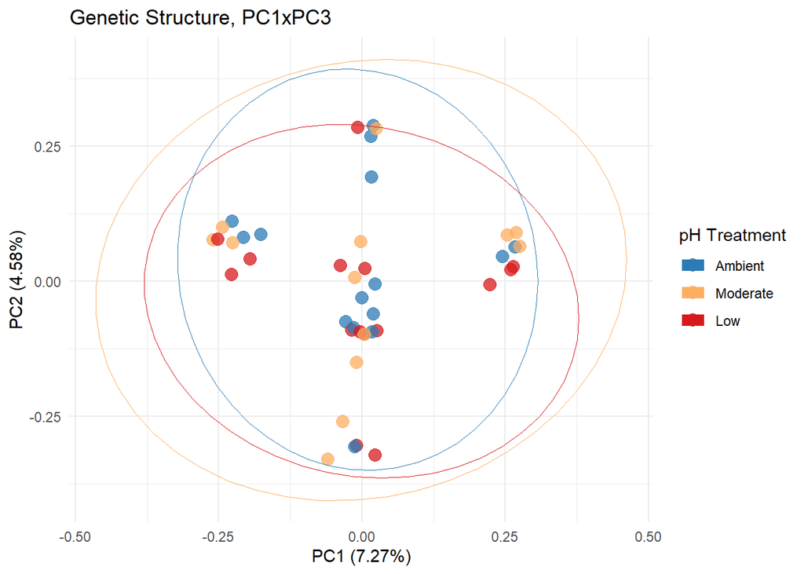

```r
# PC1 X PC3
ggplot(tab.annot.gen, aes(x=PC1.gen, y=PC3.gen)) +
  geom_point(aes(col=Treatment), size=3.5, alpha=0.75) +
  theme_minimal() + ggtitle("Genetic Structure, PC1xPC3") +
  xlab(paste("PC1 (", round(pc.percent[1], digits = 2), "%)", sep="")) +
  ylab(paste("PC2 (", round(pc.percent[3], digits = 2), "%)", sep="")) +
  theme(legend.position = "right") +
  scale_color_manual(values=c(Ambient="#2c7bb6", Moderate="#fdae61", Low="#d7191c"), name="pH Treatment") +
  guides(colour = guide_legend(override.aes = list(size=3.5))) +
  stat_ellipse(aes(col=Treatment), size=0.3)
```

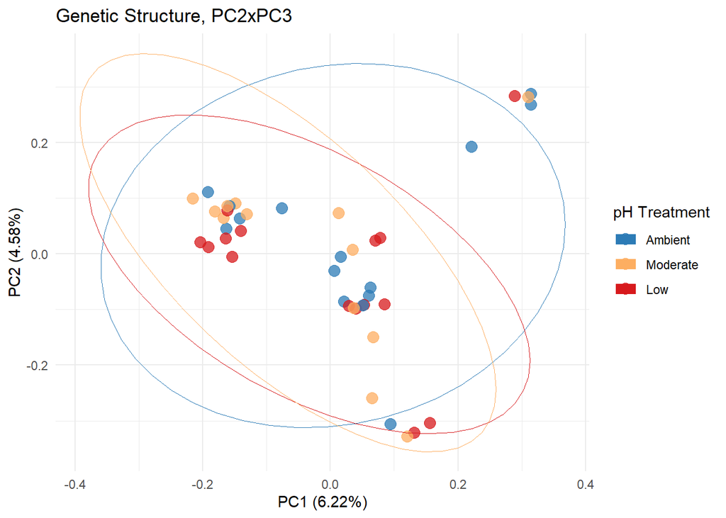

```r
# PC2 X PC3
ggplot(tab.annot.gen, aes(x=PC2.gen, y=PC3.gen)) +
  geom_point(aes(col=Treatment), size=3.5, alpha=0.75) +
  theme_minimal() + ggtitle("Genetic Structure, PC2xPC3") +
  xlab(paste("PC1 (", round(pc.percent[2], digits = 2), "%)", sep="")) +
  ylab(paste("PC2 (", round(pc.percent[3], digits = 2), "%)", sep="")) +
  theme(legend.position = "right") +
  scale_color_manual(values=c(Ambient="#2c7bb6", Moderate="#fdae61", Low="#d7191c"), name="pH Treatment") +
  guides(colour = guide_legend(override.aes = list(size=3.5))) +
  stat_ellipse(aes(col=Treatment), size=0.3)
```

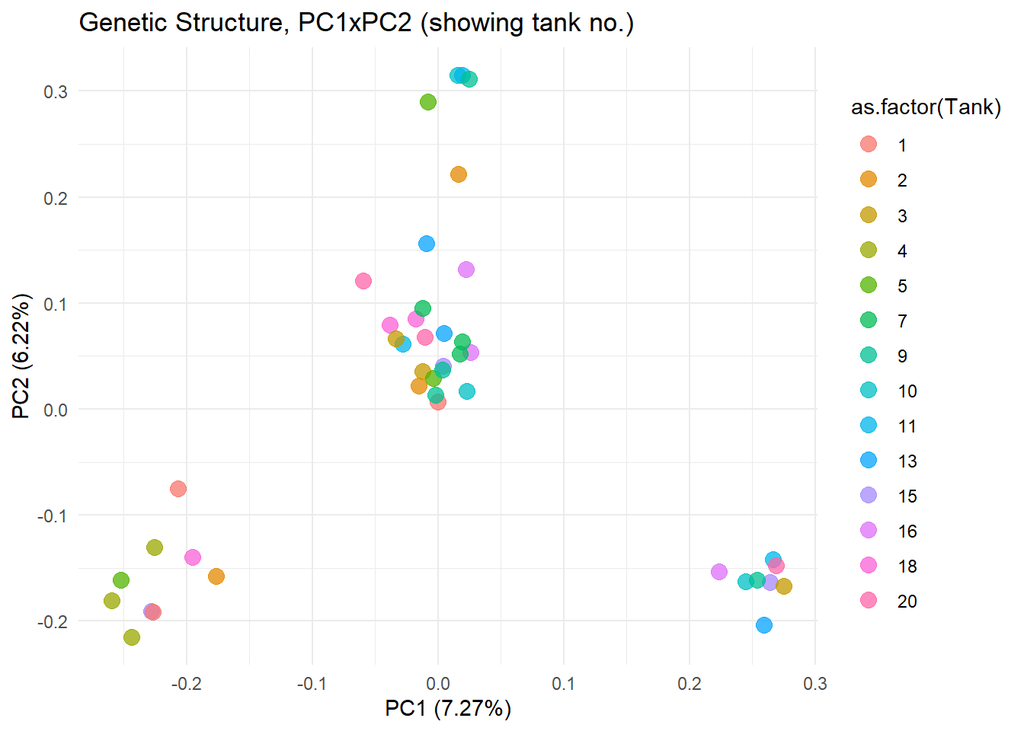

```r
# PC1 X PC2 color coded by tank
ggplot(tab.annot.gen, aes(x=PC1.gen, y=PC2.gen)) +
  geom_point(aes(col=as.factor(Tank)), size=3.5, alpha=0.75) +
  theme_minimal() + ggtitle("Genetic Structure, PC1xPC2 (showing tank no.)") +
  xlab(paste("PC1 (", round(pc.percent[1], digits = 2), "%)", sep="")) +
  ylab(paste("PC2 (", round(pc.percent[2], digits = 2), "%)", sep="")) +
  theme(legend.position = "right") +
  guides(colour = guide_legend(override.aes = list(size=3.5)))
```

```r
save(tab.annot.gen, file="../results/genotype/tab.annot.gen")
```

## cluster analysis

```r
# To perform cluster analysis on the matrix of genome-wide IBS pairwise distances,
# and determine the groups by a permutation score.
# Result= only 1 group (?)
ibs.hc <- snpgdsHCluster(snpgdsIBS(genofile, snp.id=snpset.id, num.thread=2, autosome.only=FALSE))
```

```
## Identity-By-State (IBS) analysis on genotypes:
## Excluding 0 SNP (monomorphic: TRUE, MAF: NaN, missing rate: NaN)
##     # of samples: 43
##     # of SNPs: 1,082
##     using 2 threads
## IBS:    the sum of all selected genotypes (0,1,2) = 38142
## Mon Mar 28 11:58:34 2022    (internal increment: 65536)
##
[..................................................]  0%, ETC: ---
[==================================================] 100%, completed, 0s
## Mon Mar 28 11:58:34 2022    Done.
```

```r
rv <- snpgdsCutTree(ibs.hc)
```

```
## Determine groups by permutation (Z threshold: 15, outlier threshold: 5):
## Create 1 groups.
```

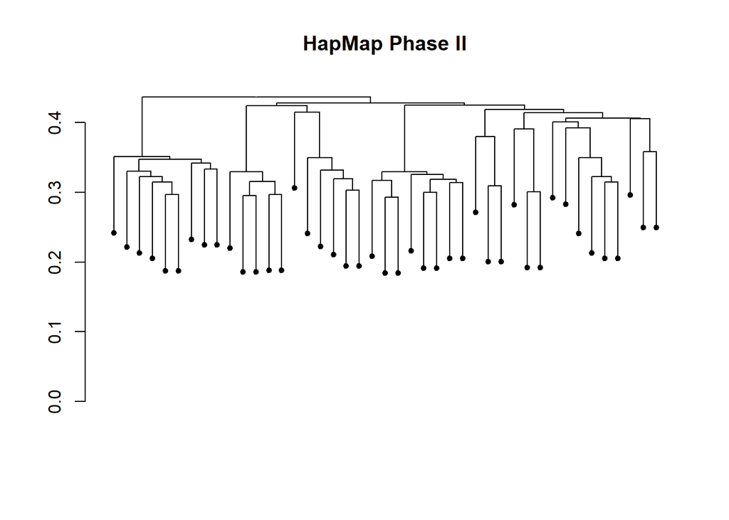

```r
plot(rv$dendrogram, leaflab="none", main="HapMap Phase II")
```

```r
# Determine groups of individuals by population information
rv2 <- snpgdsCutTree(ibs.hc, samp.group=tab.annot.gen$Treatment)
```

```
## Create 3 groups.
```

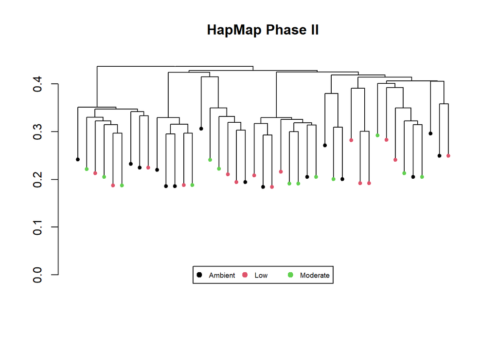

```r
plot(rv2$dendrogram, leaflab="none", main="HapMap Phase II")
legend("bottom", legend=levels(group), col=1:nlevels(group), pch=19, ncol=3, cex=0.6, pt.cex=1)
```

## Allele frequencies

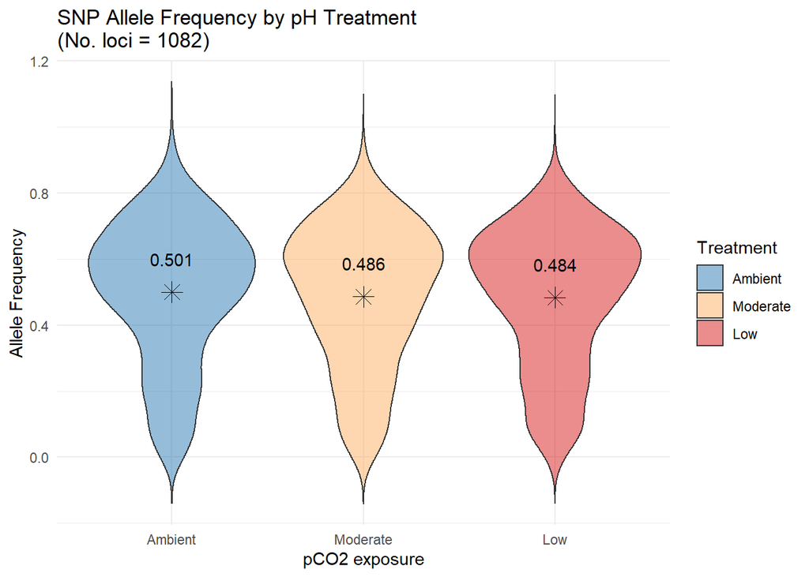

```r
AF.ambient <- snpgdsSNPRateFreq(genofile, snp.id=snpset.id, sample.id=subset(tab.annot.gen, Treatment=="Ambient")$sample.id, with.id = TRUE)

AF.moderate <- snpgdsSNPRateFreq(genofile, snp.id=snpset.id, sample.id=subset(tab.annot.gen, Treatment=="Moderate")$sample.id, with.id = TRUE)

AF.low <- snpgdsSNPRateFreq(genofile, snp.id=snpset.id, sample.id=subset(tab.annot.gen, Treatment=="Low")$sample.id, with.id = TRUE)

AFs <- rbind(
  do.call(cbind.data.frame, AF.ambient[c("snp.id", "AlleleFreq")]) %>%
    mutate(Treatment=as.factor("Ambient")),
do.call(cbind.data.frame, AF.moderate[c("snp.id", "AlleleFreq")]) %>%
  mutate(Treatment=as.factor("Moderate")),
do.call(cbind.data.frame, AF.low[c("snp.id", "AlleleFreq")]) %>%
  mutate(Treatment=as.factor("Low")))

ggplot(AFs, aes(x=Treatment, y=AlleleFreq, fill=Treatment)) + geom_violin(trim = F, alpha=0.5) +
  theme_minimal() +
  stat_summary(fun.y=mean, geom="point", shape=8, size=4, color="black", fill="black") +
  xlab("pCO2 exposure") + ylab("Allele Frequency") +
  scale_fill_manual(values = c(Ambient="#2c7bb6", Moderate="#fdae61", Low="#d7191c")) +
  ggtitle(paste("SNP Allele Frequency by pH Treatment\n",
                "(No. loci = ", length(snpset.id), ")", sep="")) +
    geom_text(data=AFs %>% group_by(Treatment) %>%
                summarize(mean=mean(AlleleFreq)),
              aes(x=Treatment, y=mean+.1, label=round(mean, 3)))
```

## Fst Calculations ### Note: snpgdsFst() returns 5 things: - sample IDs - SNP ids (i.e. indices) - “Fst” = weighted Fst estimate - “MeanFst” = average of Fst estimates across all SNPs - “FstSNP” = A vector of Fst for each SNP

```r
# Fst among all 3 treatments
Fst <- snpgdsFst(genofile, snp.id=snpset.id,
                        sample.id=tab.annot.gen$sample.id,
                  population=tab.annot.gen$Treatment,
    method="W&C84", autosome.only=FALSE, with.id = TRUE)
```

```
## Fst estimation on genotypes:
## Excluding 0 SNP (monomorphic: TRUE, MAF: NaN, missing rate: NaN)
##     # of samples: 43
##     # of SNPs: 1,082
## Method: Weir & Cockerham, 1984
## # of Populations: 3
##     Ambient (15), Low (15), Moderate (13)
```

```r
paste("Weir and Cockerham mean Fst estimate, all treatments compared: ", round(Fst$MeanFst, 5))
```

```
## [1] "Weir and Cockerham mean Fst estimate, all treatments compared:  0.02043"
```

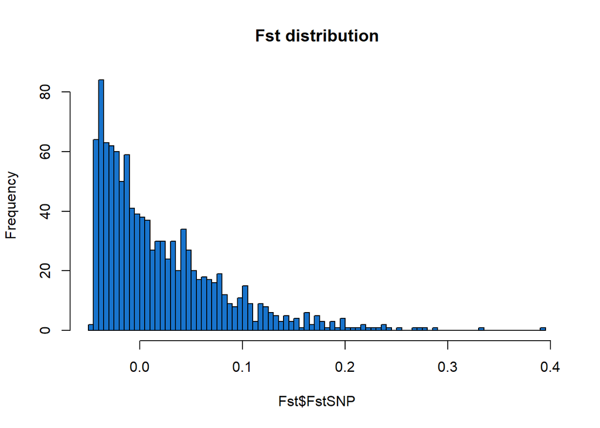

```r
hist(Fst$FstSNP, breaks = 75, main="Fst distribution", col="dodgerblue3")
```

```r
Fst.AM <- snpgdsFst(genofile, snp.id=snpset.id,
                        sample.id=subset(tab.annot.gen, Treatment %in% c("Ambient", "Moderate"))$sample.id,
               population=droplevels(subset(tab.annot.gen, Treatment %in% c("Ambient", "Moderate"))$Treatment),
    method="W&C84", autosome.only=FALSE, with.id = TRUE)
```

```
## Fst estimation on genotypes:
## Excluding 1 SNP (monomorphic: TRUE, MAF: NaN, missing rate: NaN)
##     # of samples: 28
##     # of SNPs: 1,081
## Method: Weir & Cockerham, 1984
## # of Populations: 2
##     Ambient (15), Moderate (13)
```

```r
paste("Weir and Cockerham mean Fst estimate, Ambient vs Moderate: ", round(Fst.AM$MeanFst, 5))
```

```
## [1] "Weir and Cockerham mean Fst estimate, Ambient vs Moderate:  0.01968"
```

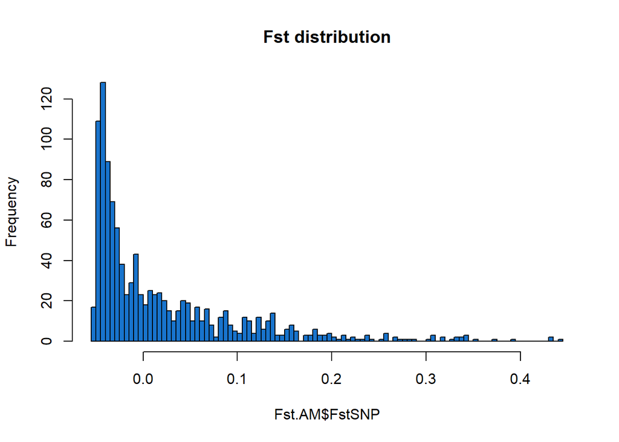

```r
hist(Fst.AM$FstSNP, breaks = 75, main="Fst distribution", col="dodgerblue3")
```

```r
Fst.AL <- snpgdsFst(genofile, snp.id=snpset.id,
                        sample.id=subset(tab.annot.gen, Treatment %in% c("Ambient", "Low"))$sample.id,
               population=droplevels(subset(tab.annot.gen, Treatment %in% c("Ambient", "Low"))$Treatment),
    method="W&C84", autosome.only=FALSE, with.id = TRUE)
```

```
## Fst estimation on genotypes:
## Excluding 0 SNP (monomorphic: TRUE, MAF: NaN, missing rate: NaN)
##     # of samples: 30
##     # of SNPs: 1,082
## Method: Weir & Cockerham, 1984
## # of Populations: 2
##     Ambient (15), Low (15)
```

```r
paste("Weir and Cockerham mean Fst estimate, Ambient vs Low: ", round(Fst.AL$MeanFst, 5))
```

```
## [1] "Weir and Cockerham mean Fst estimate, Ambient vs Low:  0.02074"
```

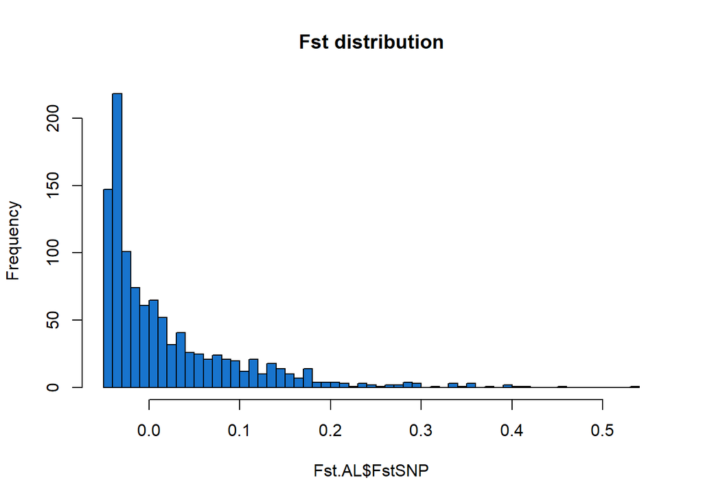

```r
hist(Fst.AL$FstSNP, breaks = 75, main="Fst distribution", col="dodgerblue3")
```

```r
Fst.ML <- snpgdsFst(genofile, snp.id=snpset.id,
                        sample.id=subset(tab.annot.gen, Treatment %in% c("Moderate", "Low"))$sample.id,
               population=droplevels(subset(tab.annot.gen, Treatment %in% c("Moderate", "Low"))$Treatment),
    method="W&C84", autosome.only=FALSE, with.id = TRUE)
```

```
## Fst estimation on genotypes:
## Excluding 1 SNP (monomorphic: TRUE, MAF: NaN, missing rate: NaN)
##     # of samples: 28
##     # of SNPs: 1,081
## Method: Weir & Cockerham, 1984
## # of Populations: 2
##     Low (15), Moderate (13)
```

```r
paste("Weir and Cockerham mean Fst estimate, Moderate vs Low: ", round(Fst.ML$MeanFst, 5))
```

```
## [1] "Weir and Cockerham mean Fst estimate, Moderate vs Low:  0.01442"
```

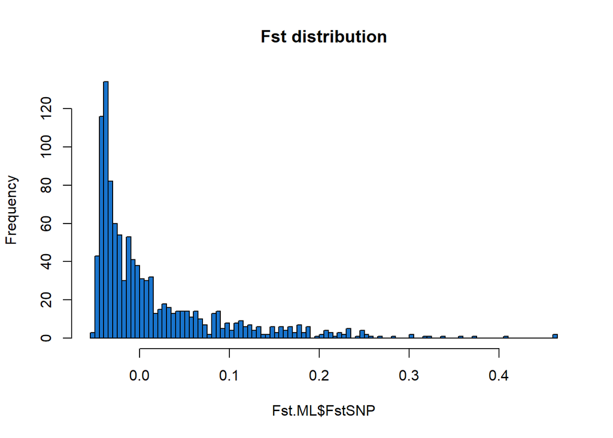

```r
hist(Fst.ML$FstSNP, breaks = 75, main="Fst distribution", col="dodgerblue3")
```

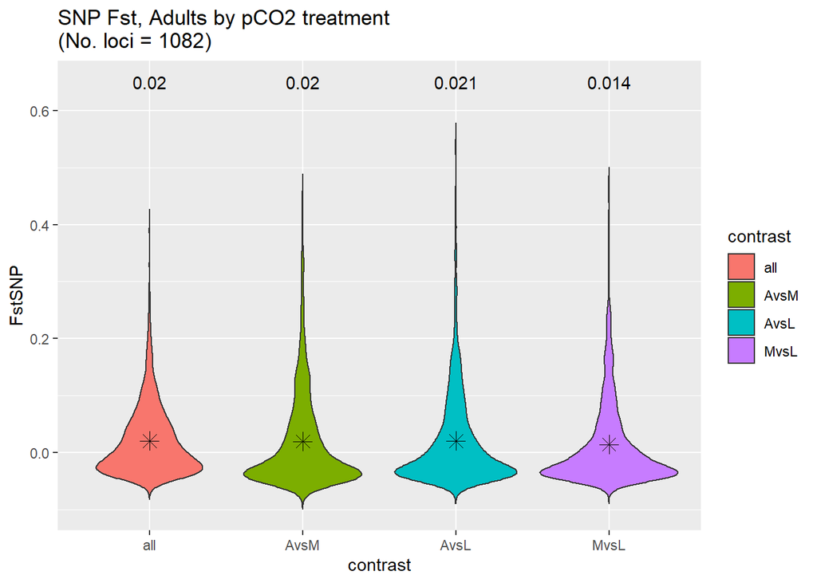

```r
Fsts <- rbind(

  do.call(cbind.data.frame, Fst[c("snp.id", "FstSNP")]) %>% mutate(contrast=as.factor("all")),

  do.call(cbind.data.frame, Fst.AM[c("snp.id", "FstSNP")]) %>% mutate(contrast=as.factor("AvsM")),

  do.call(cbind.data.frame, Fst.AL[c("snp.id", "FstSNP")]) %>% mutate(contrast=as.factor("AvsL")),

  do.call(cbind.data.frame, Fst.ML[c("snp.id", "FstSNP")]) %>% mutate(contrast=as.factor("MvsL")))

ggplot(Fsts, aes(x=contrast, y=FstSNP, fill=contrast)) + geom_violin(trim = F) +
  stat_summary(fun.y=mean, geom="point", shape=8, size=3.5, color="black", fill="black") +
  ggtitle(paste("SNP Fst, Adults by pCO2 treatment\n", "(No. loci = ", length(snpset.id), ")", sep="")) +
    geom_text(data=Fsts %>% group_by(contrast) %>% summarize(mean=mean(FstSNP)), aes(x=contrast, y=.65, label=round(mean, 3)))
```

## Adult Identity-by-state

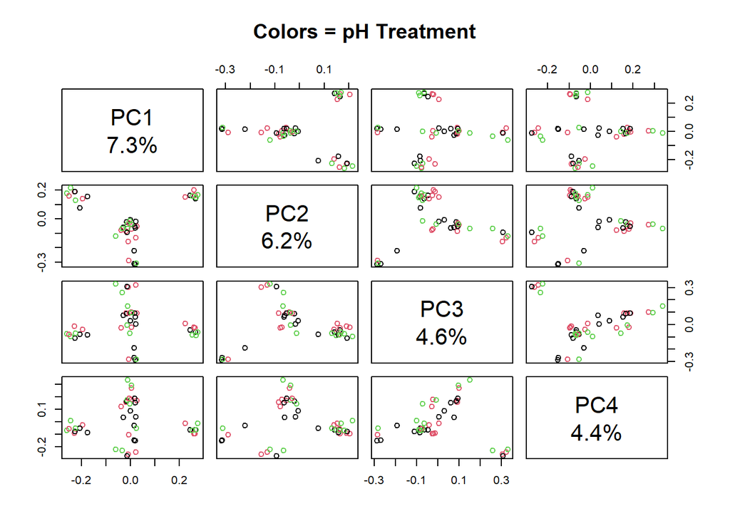

```r
lbls <- paste("PC", 1:4, "\n", format(pc.percent[1:4], digits=2), "%", sep="")
pairs(pca$eigenvect[,1:4], col=as.color(tab.annot.gen$Treatment), labels=lbls, main="Colors = pH Treatment")
```

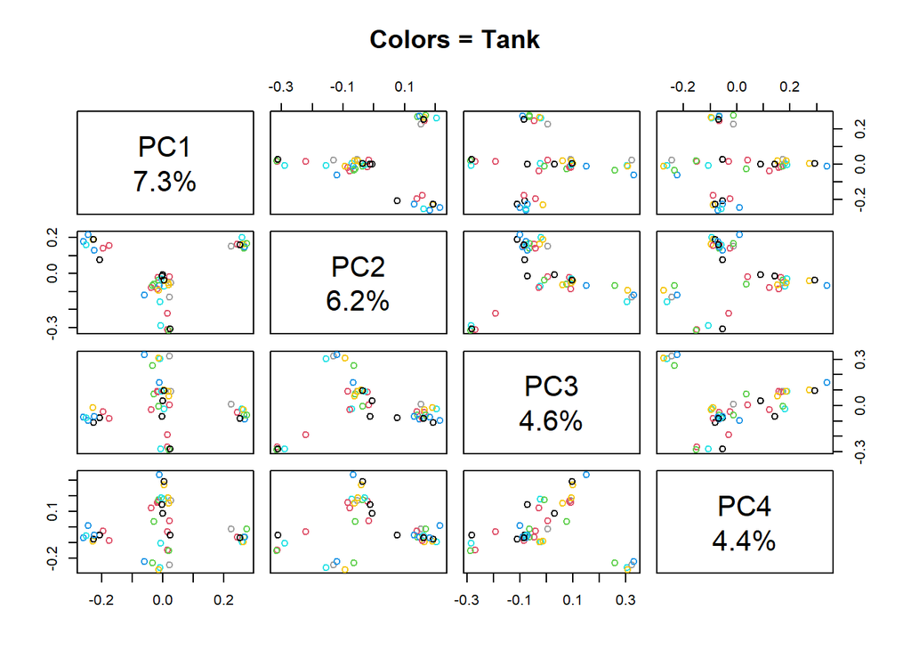

```r
pairs(pca$eigenvect[,1:4], col=as.color(tab.annot.gen$Tank), labels=lbls, main="Colors = Tank")
```

```r
ibs <- snpgdsIBS(genofile, snp.id=snpset.id, num.thread=2, autosome.only=FALSE)
```

```
## Identity-By-State (IBS) analysis on genotypes:
## Excluding 0 SNP (monomorphic: TRUE, MAF: NaN, missing rate: NaN)
##     # of samples: 43
##     # of SNPs: 1,082
##     using 2 threads
## IBS:    the sum of all selected genotypes (0,1,2) = 38142
## Mon Mar 28 11:58:36 2022    (internal increment: 65536)
##
[..................................................]  0%, ETC: ---
[==================================================] 100%, completed, 0s
## Mon Mar 28 11:58:36 2022    Done.
```

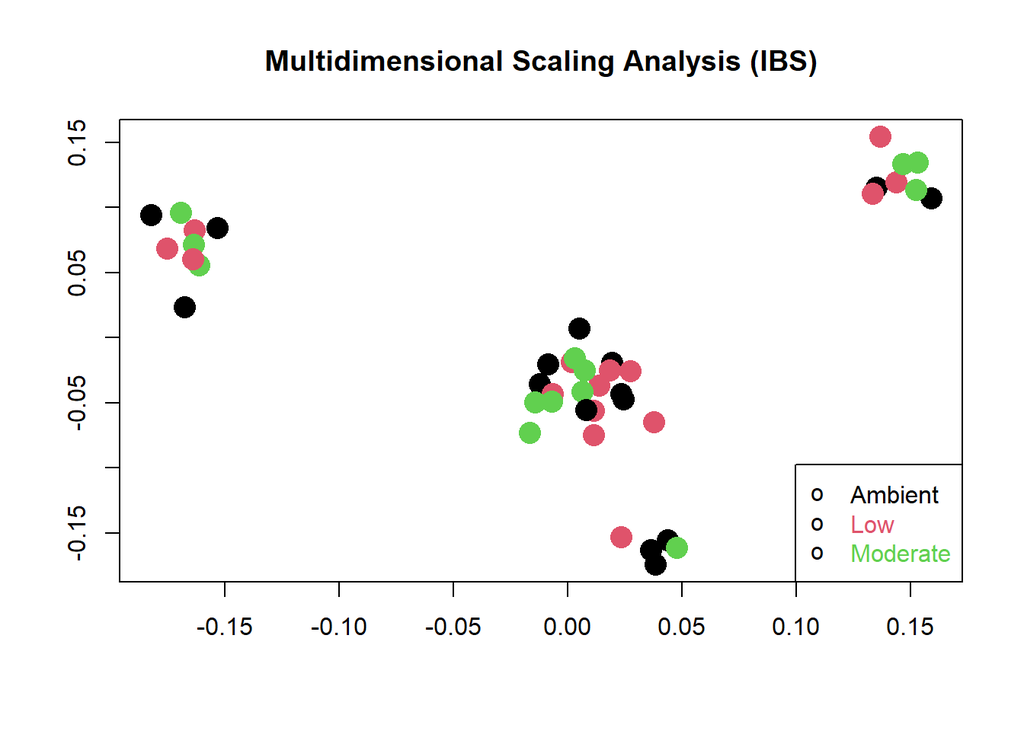

```r
pop.idx <- order(tab.annot.gen$Treatment)

#par(xpd=TRUE)
#heatmap(ibs$ibs, col=terrain.colors(16), labCol=TRUE,
#        RowSideColors=c("black","red","green","blue")[tab.annot.gen$pop_code])
#legend(0,-.05, legend=levels(tab.annot.gen$pop_code), pch="o", col=1:nlevels(tab.annot.gen$pop_code),
#       text.col=1:nlevels(tab.annot.gen$pop_code), cex=.75, ncol=4)

#Perform multidimensional scaling analysis on the matrix of genome-wide IBS pairwise distances:
loc <- cmdscale(1 - ibs$ibs, k = 2)
x <- loc[, 1]; y <- loc[, 2]

plot(x, y, col=group, xlab = "", ylab = "",
    main = "Multidimensional Scaling Analysis (IBS)", cex=2, pch=16)
#text(x, y+.01, labels=tab.annot.gen$sample.id, cex=0.7, font=2, col=as.integer(group))
legend("bottomright", legend=levels(group), pch="o", text.col=1:nlevels(group))
```

## Correlation analysis, Genetic PCAs ~ Expression PCAs

### Generage PCAs from expression data for integration

#### PCA with all genes using princomp and showing broken stick

```r
load(file = "../results/deseq2/vsd.pH") #vsd.pH
pca.princomp.expr <- prcomp(cov(assay(vsd.pH)), scale=F) #scale=F for variance-covariance matrix
pca.eigenval(pca.princomp.expr) #The Proporation of Variance = %variance
```

```
## Importance of components:
```

```
##                              PC1       PC2       PC3       PC4       PC5
## Variance(eigenvalue)   0.1971877 0.1007330 0.0130358 0.0075512 0.0032650
## Proportion of Variance 0.5823543 0.2974947 0.0384986 0.0223010 0.0096426
## Cumulative Proportion  0.5823543 0.8798489 0.9183475 0.9406485 0.9502911
## Broken-stick value     4.3267428 3.3267428 2.8267428 2.4934095 2.2434095
##                              PC6       PC7       PC8       PC9      PC10
## Variance(eigenvalue)   0.0024846 0.0021867 0.0017134 0.0011845 0.0010702
## Proportion of Variance 0.0073378 0.0064580 0.0050602 0.0034983 0.0031606
## Cumulative Proportion  0.9576289 0.9640869 0.9691471 0.9726454 0.9758060
## Broken-stick value     2.0434095 1.8767428 1.7338857 1.6088857 1.4977746
##                             PC11      PC12      PC13      PC14      PC15
## Variance(eigenvalue)   0.0008187 0.0007814 0.0005743 0.0005095 0.0004795
## Proportion of Variance 0.0024180 0.0023076 0.0016959 0.0015048 0.0014162
## Cumulative Proportion  0.9782240 0.9805316 0.9822275 0.9837323 0.9851484
## Broken-stick value     1.3977746 1.3068655 1.2235321 1.1466091 1.0751805
##                             PC16      PC17      PC18      PC19      PC20
## Variance(eigenvalue)   0.0004489 0.0003915 0.0003294 0.0003143 0.0002753
## Proportion of Variance 0.0013257 0.0011562 0.0009729 0.0009281 0.0008129
## Cumulative Proportion  0.9864741 0.9876303 0.9886032 0.9895314 0.9903443
## Broken-stick value     1.0085138 0.9460138 0.8871903 0.8316347 0.7790031
##                             PC21      PC22      PC23      PC24      PC25
## Variance(eigenvalue)   0.0002604 0.0002533 0.0002314 0.0002205 0.0002126
## Proportion of Variance 0.0007689 0.0007480 0.0006833 0.0006512 0.0006279
## Cumulative Proportion  0.9911132 0.9918612 0.9925445 0.9931957 0.9938236
## Broken-stick value     0.7290031 0.6813841 0.6359296 0.5924513 0.5507846
##                             PC26      PC27      PC28      PC29      PC30
## Variance(eigenvalue)   0.0002043 0.0001962 0.0001621 0.0001531 0.0001517
## Proportion of Variance 0.0006034 0.0005796 0.0004788 0.0004521 0.0004480
## Cumulative Proportion  0.9944270 0.9950066 0.9954855 0.9959375 0.9963855
## Broken-stick value     0.5107846 0.4723231 0.4352861 0.3995718 0.3650890
##                             PC31      PC32      PC33      PC34      PC35
## Variance(eigenvalue)   0.0001333 0.0001325 0.0001264 0.0001249 0.0001170
## Proportion of Variance 0.0003937 0.0003913 0.0003732 0.0003689 0.0003456
## Cumulative Proportion  0.9967792 0.9971704 0.9975436 0.9979125 0.9982581
## Broken-stick value     0.3317557 0.2994976 0.2682476 0.2379446 0.2085328
##                             PC36      PC37      PC38      PC39      PC40
## Variance(eigenvalue)   0.0001130 0.0001113 0.0001001 0.0000944 0.0000905
## Proportion of Variance 0.0003337 0.0003288 0.0002956 0.0002787 0.0002672
## Cumulative Proportion  0.9985918 0.9989206 0.9992162 0.9994948 0.9997621
## Broken-stick value     0.1799614 0.1521836 0.1251566 0.0988408 0.0731998
##                             PC41      PC42
## Variance(eigenvalue)   0.0000806 0.0000000
## Proportion of Variance 0.0002379 0.0000000
## Cumulative Proportion  1.0000000 1.0000000
## Broken-stick value     0.0481998 0.0238095
```

```r
(pc.percent <- pca.eigenval(pca.princomp.expr)[2,1:4]*100)
```

```
## Importance of components:
```

```
##      PC1      PC2      PC3      PC4
## 58.23543 29.74947  3.84986  2.23010
```

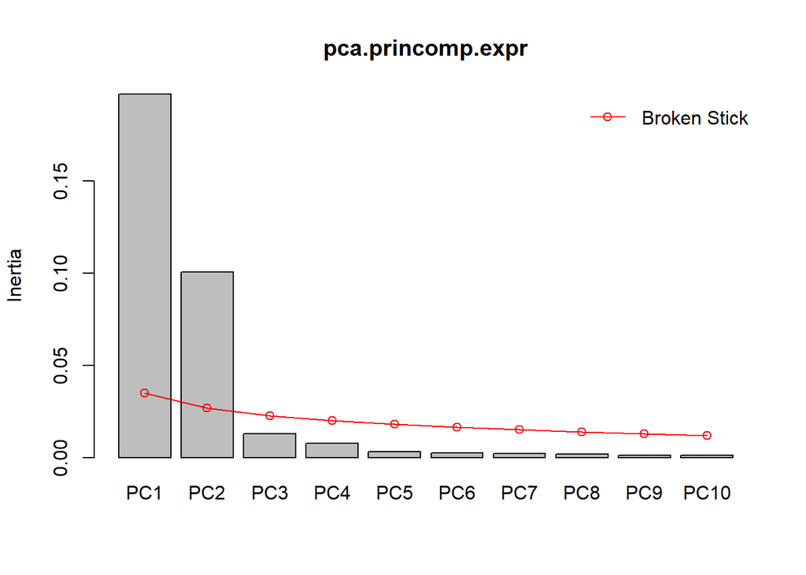

```r
screeplot(pca.princomp.expr, bstick=TRUE) #looks like PC 1-2 are significant, but also pull the 3rd
```

```r
tab.expr <- data.frame(sample.id = colnames(assay(vsd.pH)),
    PC1.expr = pca.princomp.expr$x[,1],    # the first eigenvector
    PC2.expr = pca.princomp.expr$x[,2],    # the second eigenvector
    PC3.expr = pca.princomp.expr$x[,3],    # the third eigenvector
    PC4.expr = pca.princomp.expr$x[,4],    # the fourth eigenvector
    stringsAsFactors = FALSE)
shapiro.test(pca.princomp.expr$x) #multivariate normality not met
```

```
##
##  Shapiro-Wilk normality test
##
## data:  pca.princomp.expr$x
## W = 0.44877, p-value < 2.2e-16
```

```r
tab.expr.annot <- left_join(tab.expr, sample.info, by=c("sample.id"="Sample")) %>% droplevels()
group.expr <- as.factor(tab.expr.annot$Treatment)
```

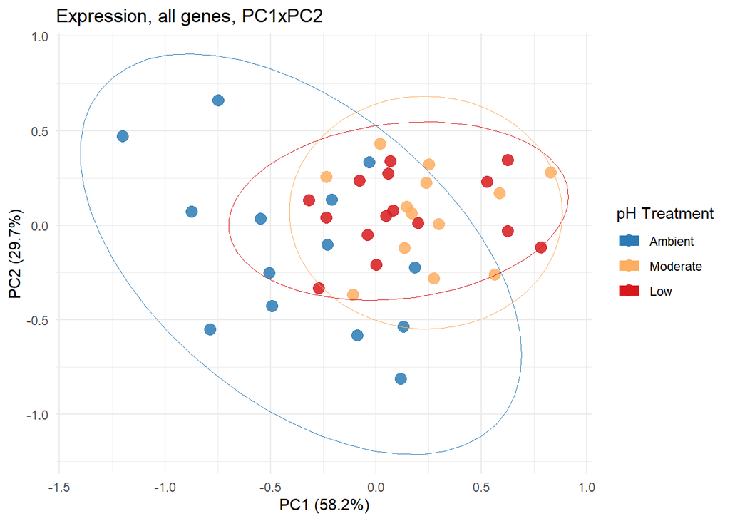

```r
ggplot(tab.expr.annot, aes(x=PC1.expr, y=PC2.expr)) +
  geom_point(aes(col=Treatment), size=3.5, alpha=0.85) +
  theme_minimal() + ggtitle("Expression, all genes, PC1xPC2") +
  xlab(paste("PC1 (", round(pc.percent[1], digits = 1), "%)", sep="")) +
  ylab(paste("PC2 (", round(pc.percent[2], digits = 1), "%)", sep="")) +
  theme(legend.position = "right") +
  scale_color_manual(values = c(Ambient="#2c7bb6", Moderate="#fdae61", Low="#d7191c"), name="pH Treatment") +
  guides(colour = guide_legend(override.aes = list(size=3.5))) +
  stat_ellipse(aes(color=Treatment), size=0.3)
```

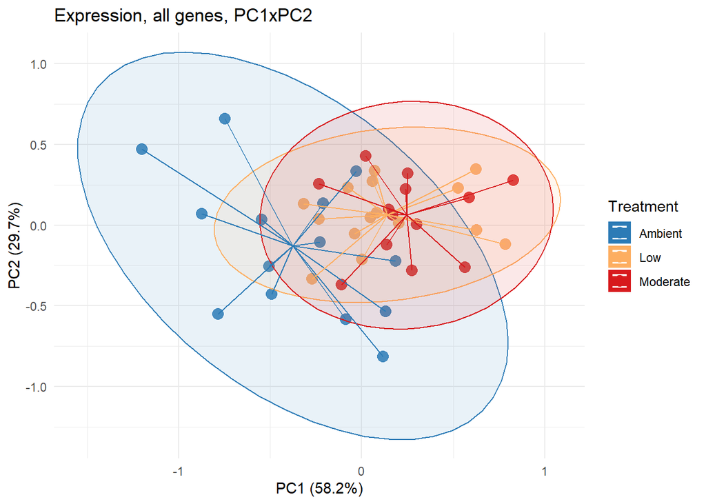

```r
save(tab.expr.annot, file="../results/genotype/tab.expr.annot")

# GGSCATTER with ellipses and stars
ggscatter(tab.expr.annot, x="PC1.expr", y="PC2.expr",
          color="Treatment", size=3.5, alpha=0.85,
           palette = c("#2c7bb6","#fdae61", "#d7191c"),
   ellipse = TRUE, star.plot = TRUE) +
  theme_minimal() + ggtitle("Expression, all genes, PC1xPC2") +
  xlab(paste("PC1 (", round(pc.percent[1], digits = 1), "%)", sep="")) +
  ylab(paste("PC2 (", round(pc.percent[2], digits = 1), "%)", sep="")) +
  theme(legend.position = "right") +
  guides(colour = guide_legend(override.aes = list(size=3.5)))
```

## PCA with gene set that are DEGs among any pH comparison

```r
# load in DEG lists
load(file = "../results/deseq2/diffex.AM")
load(file = "../results/deseq2/diffex.AL")
load(file = "../results/deseq2/diffex.ML")

pca.princomp.expr.pH <-
  princomp(cov(assay(vsd.pH[unique(c(rownames(diffex.AM),rownames(diffex.AL),rownames(diffex.ML))),])))
pca.eigenval(pca.princomp.expr.pH) #The Proporation of Variance = %variance
```

```
## Importance of components:
```

```
##                             [,1]      [,2]      [,3]      [,4]      [,5]
## Variance(eigenvalue)   2.1297512 0.4480297 0.0413377 0.0216129 0.0162686
## Proportion of Variance 0.7925553 0.1667276 0.0153832 0.0080429 0.0060541
## Cumulative Proportion  0.7925553 0.9592829 0.9746661 0.9827090 0.9887631
## Broken-stick value     4.3267428 3.3267428 2.8267428 2.4934095 2.2434095
##                             [,6]      [,7]      [,8]      [,9]     [,10]
## Variance(eigenvalue)   0.0096983 0.0057240 0.0027098 0.0022558 0.0016530
## Proportion of Variance 0.0036091 0.0021301 0.0010084 0.0008395 0.0006151
## Cumulative Proportion  0.9923722 0.9945023 0.9955108 0.9963502 0.9969654
## Broken-stick value     2.0434095 1.8767428 1.7338857 1.6088857 1.4977746
##                            [,11]     [,12]     [,13]     [,14]     [,15]
## Variance(eigenvalue)   0.0010484 0.0010037 0.0007449 0.0007080 0.0005674
## Proportion of Variance 0.0003901 0.0003735 0.0002772 0.0002635 0.0002111
## Cumulative Proportion  0.9973555 0.9977290 0.9980062 0.9982697 0.9984808
## Broken-stick value     1.3977746 1.3068655 1.2235321 1.1466091 1.0751805
##                            [,16]     [,17]     [,18]     [,19]     [,20]
## Variance(eigenvalue)   0.0004085 0.0003656 0.0003441 0.0002999 0.0002710
## Proportion of Variance 0.0001520 0.0001360 0.0001281 0.0001116 0.0001008
## Cumulative Proportion  0.9986328 0.9987689 0.9988969 0.9990085 0.9991093
## Broken-stick value     1.0085138 0.9460138 0.8871903 0.8316347 0.7790031
##                            [,21]     [,22]     [,23]     [,24]     [,25]
## Variance(eigenvalue)   0.0002385 0.0002129 0.0002011 0.0001816 0.0001637
## Proportion of Variance 0.0000888 0.0000792 0.0000748 0.0000676 0.0000609
## Cumulative Proportion  0.9991981 0.9992773 0.9993522 0.9994198 0.9994807
## Broken-stick value     0.7290031 0.6813841 0.6359296 0.5924513 0.5507846
##                            [,26]     [,27]     [,28]     [,29]     [,30]
## Variance(eigenvalue)   0.0001538 0.0001349 0.0001297 0.0001117 0.0001032
## Proportion of Variance 0.0000572 0.0000502 0.0000483 0.0000416 0.0000384
## Cumulative Proportion  0.9995379 0.9995881 0.9996364 0.9996779 0.9997164
## Broken-stick value     0.5107846 0.4723231 0.4352861 0.3995718 0.3650890
##                            [,31]     [,32]     [,33]     [,34]     [,35]
## Variance(eigenvalue)   0.0000964 0.0000924 0.0000866 0.0000798 0.0000707
## Proportion of Variance 0.0000359 0.0000344 0.0000322 0.0000297 0.0000263
## Cumulative Proportion  0.9997522 0.9997866 0.9998189 0.9998486 0.9998749
## Broken-stick value     0.3317557 0.2994976 0.2682476 0.2379446 0.2085328
##                            [,36]     [,37]     [,38]     [,39]     [,40]
## Variance(eigenvalue)   0.0000686 0.0000661 0.0000555 0.0000520 0.0000499
## Proportion of Variance 0.0000255 0.0000246 0.0000206 0.0000193 0.0000186
## Cumulative Proportion  0.9999004 0.9999250 0.9999456 0.9999650 0.9999835
## Broken-stick value     0.1799614 0.1521836 0.1251566 0.0988408 0.0731998
##                            [,41]     [,42]
## Variance(eigenvalue)   0.0000443 0.0000000
## Proportion of Variance 0.0000165 0.0000000
## Cumulative Proportion  1.0000000 1.0000000
## Broken-stick value     0.0481998 0.0238095
```

```r
(pc.percent.pH <- pca.eigenval(pca.princomp.expr.pH)[2,1:4]*100)
```

```
## Importance of components:
```

```
## [1] 79.25553 16.67276  1.53832  0.80429
```

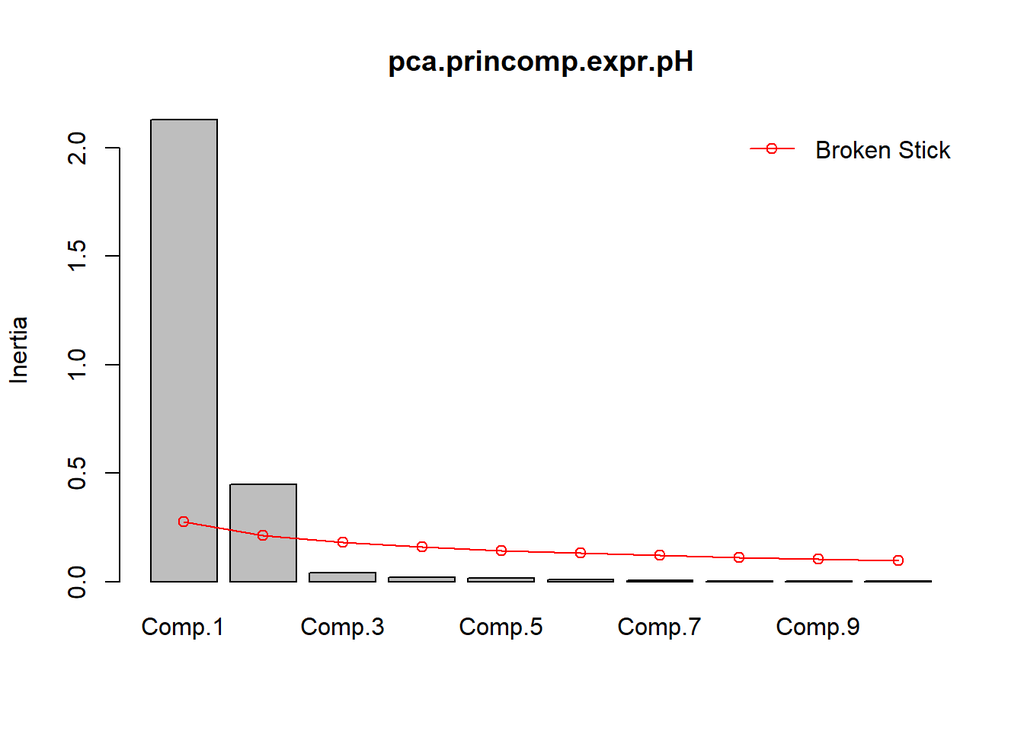

```r
screeplot(pca.princomp.expr.pH, bstick=TRUE) #looks like PC 1 & 2
```

```r
tab.expr.pH <- data.frame(sample.id = colnames(assay(vsd.pH)),
    PC1.degs = pca.princomp.expr.pH$scores[,1],    # the first eigenvector
    PC2.degs = pca.princomp.expr.pH$scores[,2],    # the second eigenvector
    PC3.degs = pca.princomp.expr.pH$scores[,3],    # the third eigenvector
    PC4.degs = pca.princomp.expr.pH$scores[,4],    # the third eigenvector
    stringsAsFactors = FALSE)
tab.expr.pH.annot <- left_join(tab.expr.pH, sample.info, by=c("sample.id"="Sample")) %>% droplevels()
group.pH.expr <- as.factor(tab.expr.pH.annot$Treatment)
```

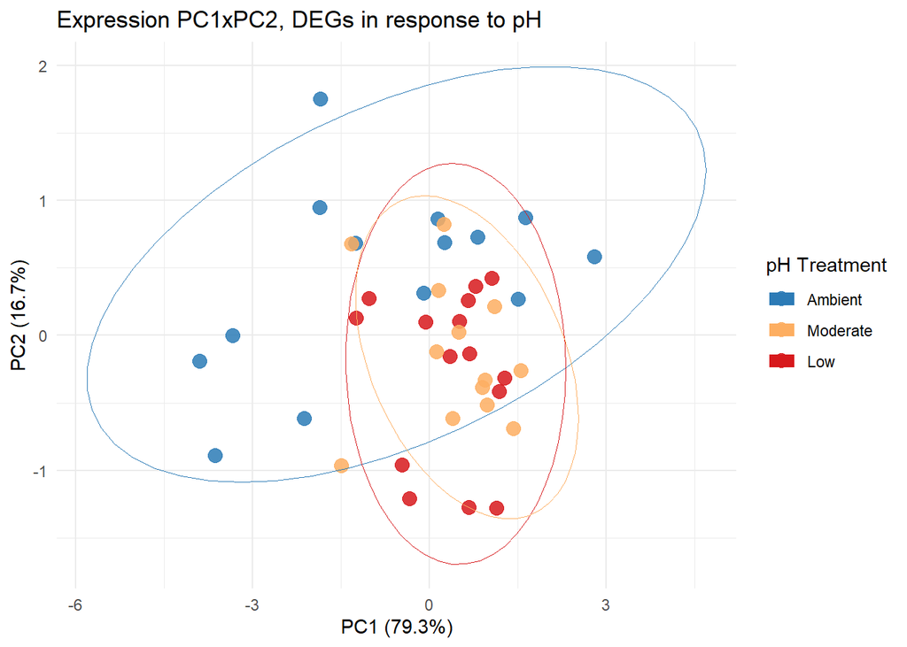

```r
ggplot(tab.expr.pH.annot, aes(x=PC1.degs, y=PC2.degs)) +
  geom_point(aes(col=Treatment), size=3.5, alpha=0.85) +
  theme_minimal() + ggtitle("Expression PC1xPC2, DEGs in response to pH") +
  xlab(paste("PC1 (", round(pc.percent.pH[1], digits = 1), "%)", sep="")) +
  ylab(paste("PC2 (", round(pc.percent.pH[2], digits = 1), "%)", sep="")) +
  theme(legend.position = "right") +
  scale_color_manual(values = c(Ambient="#2c7bb6", Moderate="#fdae61", Low="#d7191c"), name="pH Treatment") +
  guides(colour = guide_legend(override.aes = list(size=3.5))) +
  stat_ellipse(aes(color=Treatment), size=0.3)
```

```r
save(tab.expr.pH.annot, file="../results/genotype/tab.expr.pH.annot")
```

## Merge PC axes from genetic analyis, expression analysis using all data, and expression analysis using DEGs only

```r
PCA.merged <- left_join(left_join(
  tab.annot.gen %>% select(sample.id, Treatment, Tank, starts_with("PC")),
  tab.expr.annot %>% select(starts_with("PC"),sample.id), by=c("sample.id")),
  tab.expr.pH.annot %>% select(starts_with("PC"),sample.id), by=c("sample.id"))
```

## Examine correlation among genetic and expression PC axes

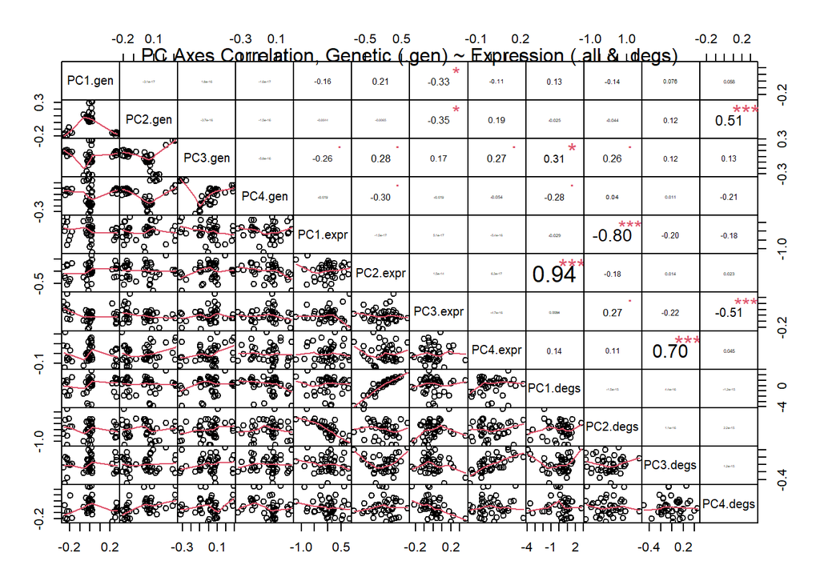

```r
chart.Correlation(PCA.merged %>% select(starts_with("PC")), histogram=F, pch=19, method = "pearson")
mtext("PC Axes Correlation, Genetic (.gen) ~ Expression (.all & .degs)", side=3, line=1.25)
```

Correlated PC axes: - PC2.gen x PC4.degs (positive correlation, highly significant) - PC1.gen x PC3 expr (negativel ycorrelated, modestly significant) - PC2.gen x PC3 expr (negativel ycorrelated, modestly significant)

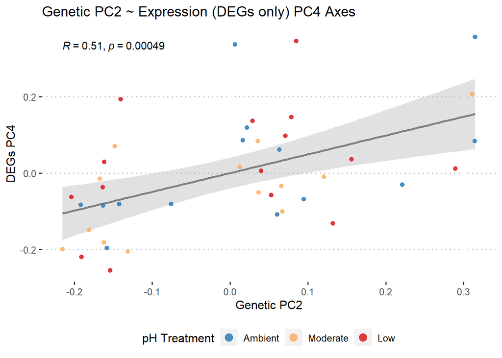

```r
# PCA.merged.4plots <- PCA.merged %>% dplyr::select(PC1.gen, PC2.gen, PC3.expr, PC4.degs) %>%
#   pivot_longer(cols = c(PC3.expr, PC4.degs), values_to = "score", names_to = "PC.expr") %>%
#   mutate(PC.expr=as.factor(PC.expr))

# Most significant correlation, PC2.gen x PC4.degs
ggscatter(PCA.merged, x="PC2.gen", y="PC4.degs", add="reg.line", conf.int = TRUE,
          color="white",
          add.params = list(color = "gray50", fill = "gray70")) +
    ggtitle("Genetic PC2 ~ Expression (DEGs only) PC4 Axes") +
  xlab("Genetic PC2") + ylab("DEGs PC4") +
  stat_cor(method = "pearson", show.legend=FALSE) +
  theme_pubclean() +theme(legend.position = "bottom") +
  scale_color_manual(values=c(Ambient="#2c7bb6", Moderate="#fdae61", Low="#d7191c"), name="pH Treatment") +
  guides(colour = guide_legend(override.aes = list(size=3.5))) +
  geom_point(aes(col=Treatment), alpha=0.85, size=1.8)
```

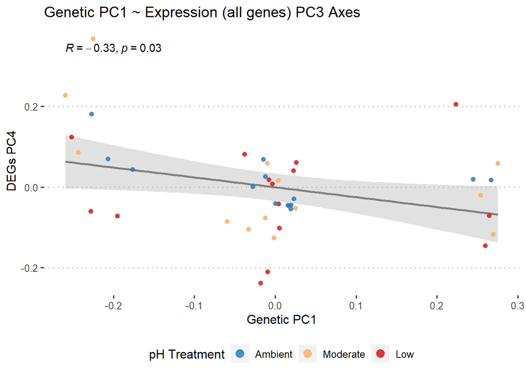

```r
# Modestly sign. correlation
ggscatter(PCA.merged, x="PC1.gen", y="PC3.expr", add="reg.line", conf.int = TRUE,
          color="white",
          add.params = list(color = "gray50", fill = "gray70")) +
    ggtitle("Genetic PC1 ~ Expression (all genes) PC3 Axes") +
  xlab("Genetic PC1") + ylab("DEGs PC4") +
  stat_cor(method = "pearson", show.legend=FALSE) +
  theme_pubclean() +theme(legend.position = "bottom") +
  scale_color_manual(values=c(Ambient="#2c7bb6", Moderate="#fdae61", Low="#d7191c"), name="pH Treatment") +
  guides(colour = guide_legend(override.aes = list(size=3.5))) +
  geom_point(aes(col=Treatment), alpha=0.85, size=1.8)
```

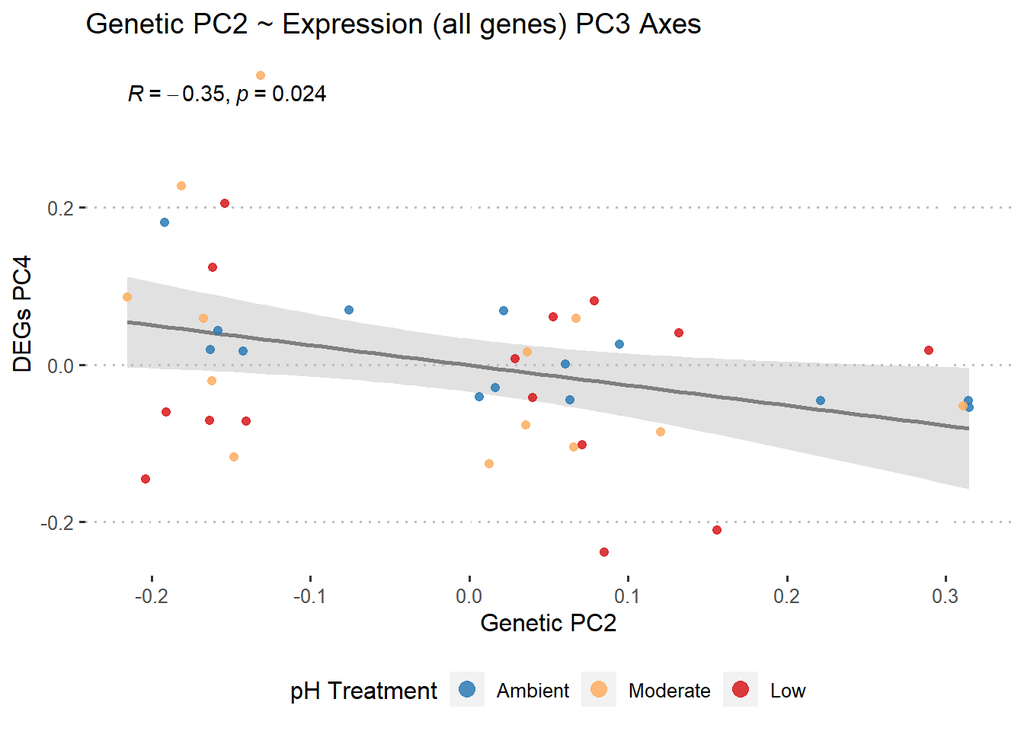

```r
# Modestly sign. correlation
ggscatter(PCA.merged, x="PC2.gen", y="PC3.expr", add="reg.line", conf.int = TRUE,
          color="white",
          add.params = list(color = "gray50", fill = "gray70")) +
    ggtitle("Genetic PC2 ~ Expression (all genes) PC3 Axes") +
  xlab("Genetic PC2") + ylab("DEGs PC4") +
  stat_cor(method = "pearson", show.legend=FALSE) +
  theme_pubclean() +theme(legend.position = "bottom") +
  scale_color_manual(values=c(Ambient="#2c7bb6", Moderate="#fdae61", Low="#d7191c"), name="pH Treatment") +
  guides(colour = guide_legend(override.aes = list(size=3.5))) +
  geom_point(aes(col=Treatment), alpha=0.85, size=1.8)
```

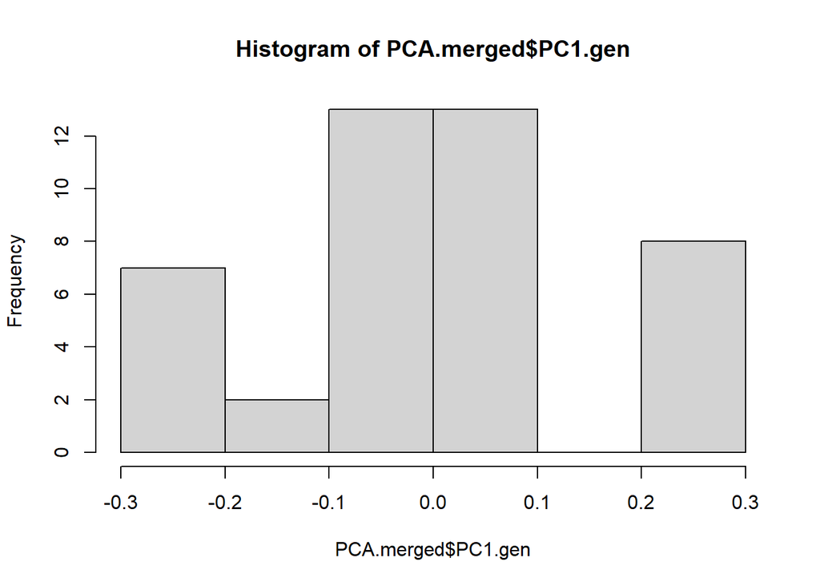

```r
# Run linear models
# Normal?
hist(PCA.merged$PC1.gen)
```

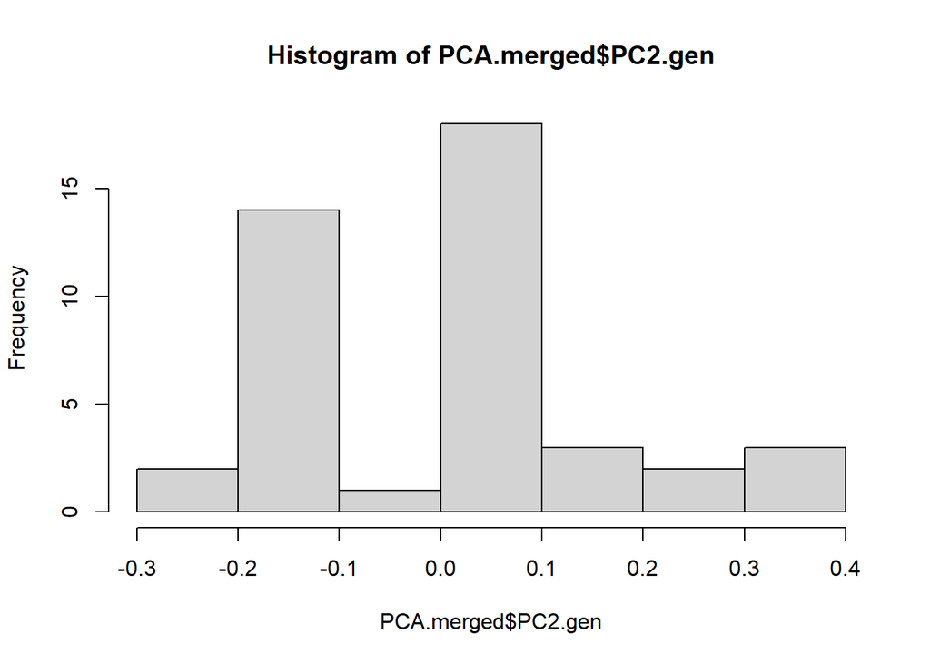

```r
hist(PCA.merged$PC2.gen)
```

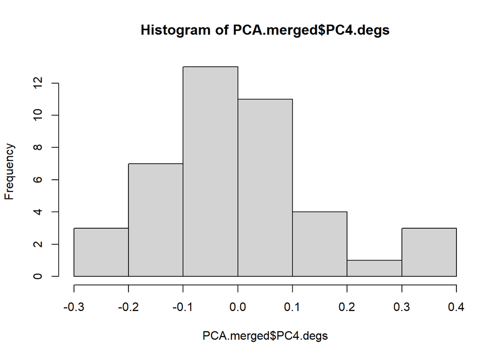

```r
hist(PCA.merged$PC4.degs)
```

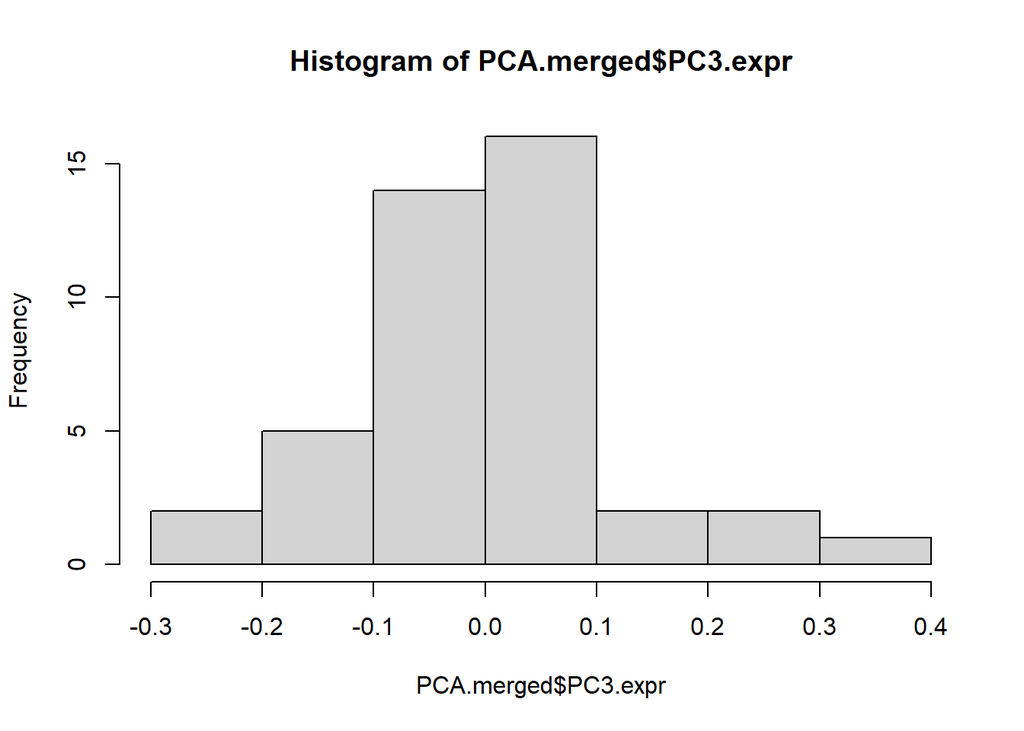

```r
hist(PCA.merged$PC3.expr)
```

```r
shapiro.test(PCA.merged$PC1.gen)
```

```
##
##  Shapiro-Wilk normality test
##
## data:  PCA.merged$PC1.gen
## W = 0.87274, p-value = 0.0002057
```

```r
shapiro.test(PCA.merged$PC2.gen)
```

```
##
##  Shapiro-Wilk normality test
##
## data:  PCA.merged$PC2.gen
## W = 0.90936, p-value = 0.002436
```

```r
shapiro.test(PCA.merged$PC4.degs)
```

```
##
##  Shapiro-Wilk normality test
##
## data:  PCA.merged$PC4.degs
## W = 0.95674, p-value = 0.1128
```

```r
shapiro.test(PCA.merged$PC3.expr)
```

```
##
##  Shapiro-Wilk normality test
##
## data:  PCA.merged$PC3.expr
## W = 0.95361, p-value = 0.08705
```

```r
# Examine linear relationship between Expression PC axes and genetic PC axes, also testing for effect of & interaction with Treatment
anova(lm(PC4.degs ~ PC2.gen*Treatment, data=PCA.merged))
```

```
## Analysis of Variance Table
##
## Response: PC4.degs
##                   Df  Sum Sq  Mean Sq F value    Pr(>F)
## PC2.gen            1 0.24016 0.240161 13.5047 0.0007693 ***
## Treatment          2 0.01828 0.009141  0.5140 0.6024113
## PC2.gen:Treatment  2 0.00909 0.004544  0.2555 0.7758947
## Residuals         36 0.64021 0.017784
## ---
## Signif. codes:  0 '***' 0.001 '**' 0.01 '*' 0.05 '.' 0.1 ' ' 1
```

```r
anova(lm(PC3.expr ~ PC1.gen*Treatment, data=PCA.merged))
```

```
## Analysis of Variance Table
##
## Response: PC3.expr
##                   Df  Sum Sq  Mean Sq F value  Pr(>F)
## PC1.gen            1 0.05978 0.059777  5.0485 0.03087 *
## Treatment          2 0.01582 0.007911  0.6681 0.51891
## PC1.gen:Treatment  2 0.03261 0.016306  1.3772 0.26527
## Residuals         36 0.42626 0.011840
## ---
## Signif. codes:  0 '***' 0.001 '**' 0.01 '*' 0.05 '.' 0.1 ' ' 1
```

```r
anova(lm(PC3.expr ~ PC2.gen*Treatment, data=PCA.merged))
```

```
## Analysis of Variance Table
##
## Response: PC3.expr
##                   Df  Sum Sq  Mean Sq F value  Pr(>F)
## PC2.gen            1 0.06499 0.064986  5.3913 0.02601 *
## Treatment          2 0.01854 0.009271  0.7691 0.47088
## PC2.gen:Treatment  2 0.01700 0.008500  0.7052 0.50072
## Residuals         36 0.43394 0.012054
## ---
## Signif. codes:  0 '***' 0.001 '**' 0.01 '*' 0.05 '.' 0.1 ' ' 1
```